# Analyse exploratoire du Jeu de Données d'Attrition des Employés

### A-

#### 1. Dimensions, Valeurs Manquantes et Attributs Constants

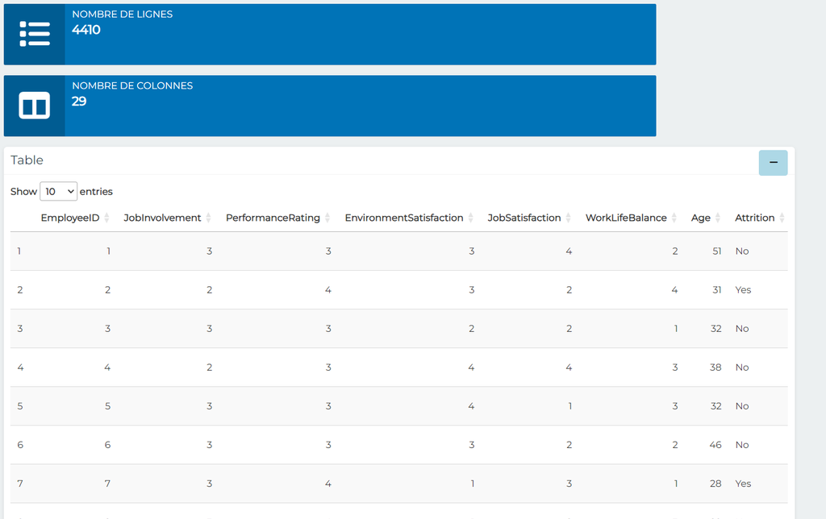

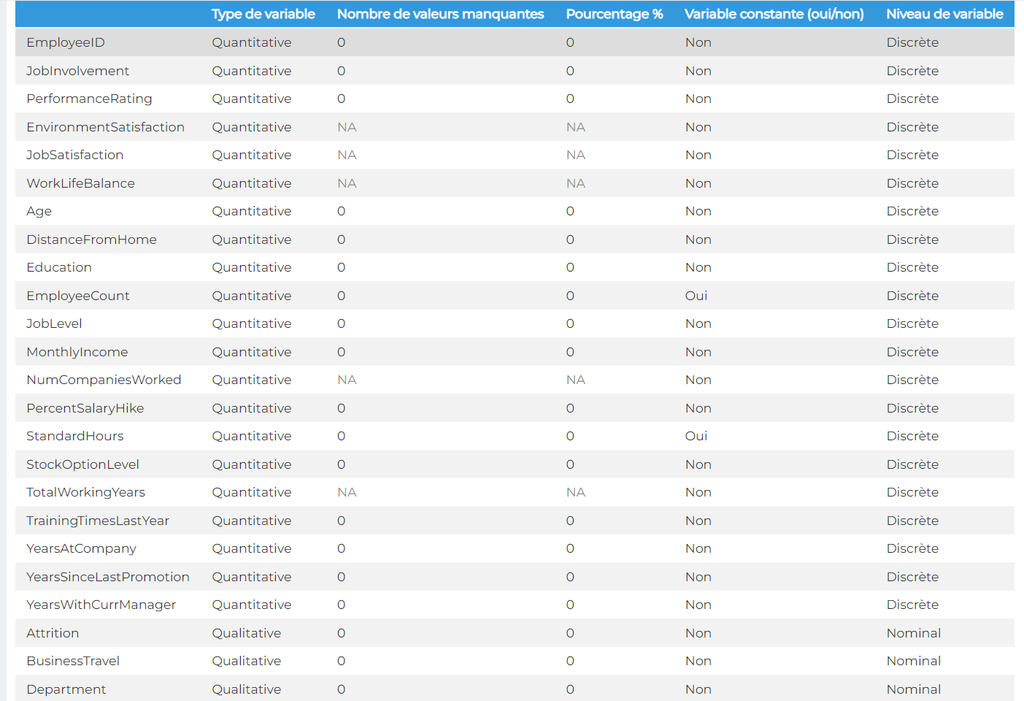

[output not shown]

### 2 Proportion des individus ayant quitté l'entreprise (Attrition)

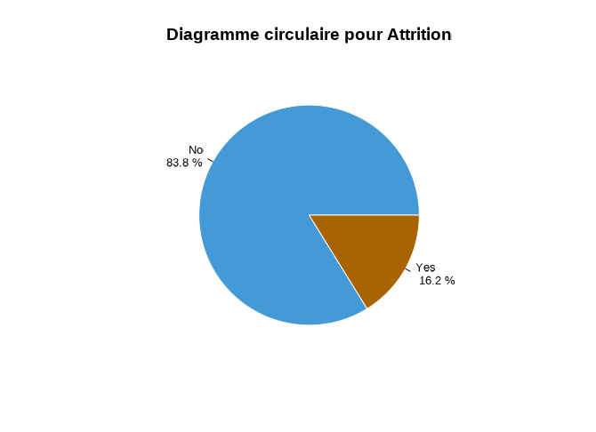

- **No** : La majorité des individus, environ 83.8 %, sont restés dans l'entreprise.
- **Yes** : Environ 16.2 % des individus ont quitté l'entreprise.

#### 3. Analyse des variables catégorielles

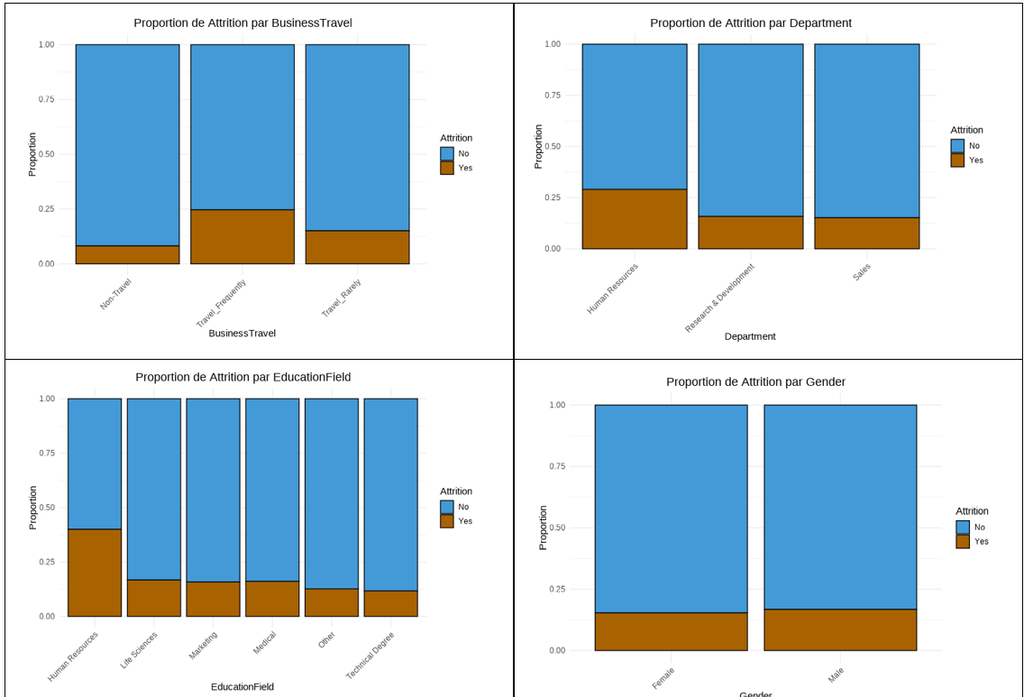

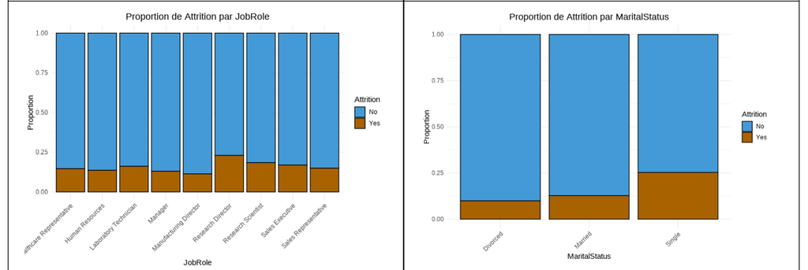

#### 4. Analyse des variables numériques

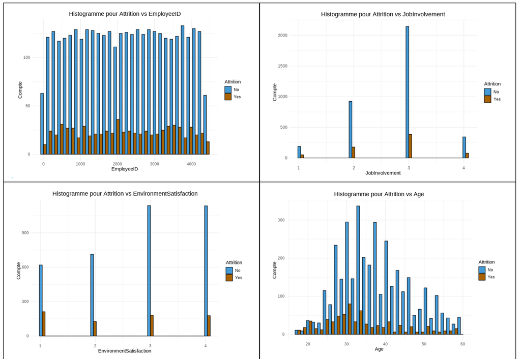

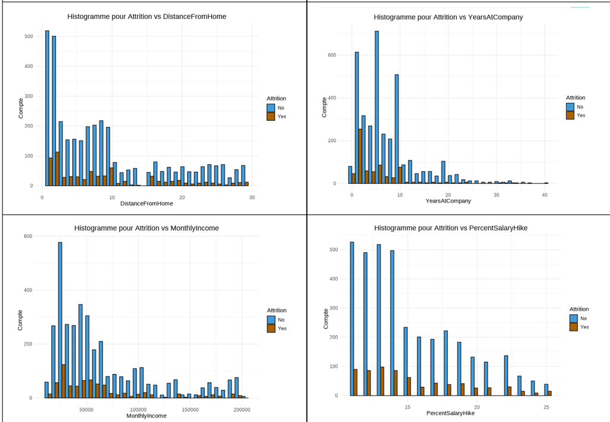

## 5. Matrice de corrélation des attributs

## Analyse de la matrice de corrélation

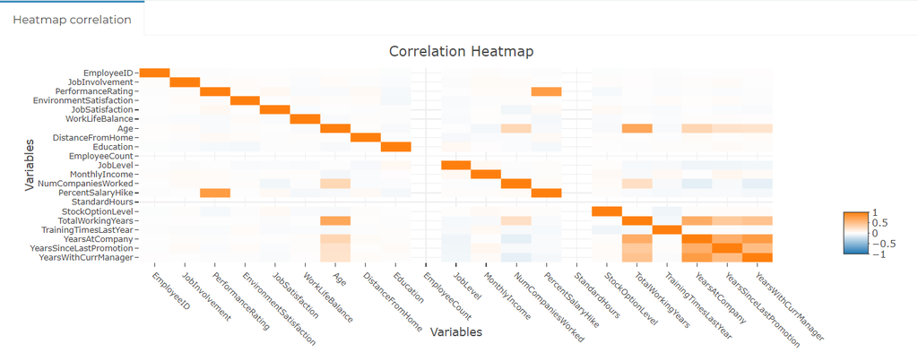

## Conclusions globales

### Variables influentes

- Variables clés pour la prédiction de l'attrition :
  - **Age**, **MonthlyIncome**, **YearsAtCompany**
  - Variables catégorielles : **BusinessTravel**, **JobRole**, **MaritalStatus**
- Ces variables devraient être priorisées dans l'élaboration d'un modèle de prédiction

### Déséquilibre de classe

- Majorité de non-attrition dans la classe cible
- Nécessité d'utiliser des techniques adaptées pour éviter les biais dans le modèle prédictif

# Prédiction de churn

En prenant en compte uniquement les quatre variables les plus significatives, à savoir : V10, V12, V14, et V17. Voici les résultats obtenus.

# Résultats de la prédiction de l'attrition des employés

## Évaluation des modèles

Nous avons évalué cinq approches de classification sur la base de l'AUC (Area Under the Curve) pour prédire l'attrition des employés. Les modèles ont d'abord été testés avec des hyperparamètres par défaut, puis optimisés via une recherche en grille (grid search).

### Résumé des performances (Données brutes)

| Approche | Modèle | AUC par défaut | AUC après Grid Search |
| --- | --- | --- | --- |
| Arbre de décision | DT | 0.78 | 0.83 |
| Régression logistique | LR | 0.84 | 0.87 |
| SVM linéaire | SVM | 0.85 | 0.88 |
| SVM Polynomial | SVM Poly | 0.86 | 0.89 |
| SVM RBF | SVM RBF | 0.87 | 0.91 |

## Analyse des résultats

1. **Meilleure performance** : Le SVM avec noyau RBF a obtenu les meilleurs résultats, atteignant un AUC de 0.91 après optimisation.
2. **Améliorations significatives** : L'optimisation des hyperparamètres a permis d'améliorer les performances de tous les modèles, avec des gains allant de 0.03 à 0.05 en termes d'AUC.
3. **Comparaison des approches** :
   - Les variantes de SVM ont généralement surpassé les autres approches.
   - La régression logistique a montré de bonnes performances, se classant juste après les modèles SVM.
   - L'arbre de décision, bien qu'amélioré par l'optimisation, reste moins performant que les autres modèles.
4. **Robustesse des SVM** : Les trois variantes de SVM (linéaire, polynomial, RBF) ont toutes bien performé, suggérant que les SVM sont particulièrement adaptés à ce problème d'attrition.

# Sur-échantillonage et sous-échantillonage

# Résumé des performances (Données suréchantillonnées - SMOTE)

| Approche | Modèle | AUC par défaut | AUC après Grid Search |
| --- | --- | --- | --- |
| Arbre de décision | DT | 0.88 | 0.91 |
| Régression logistique | LG | 0.93 | 0.95 |
| SVM linéaire | SVM linéaire | 0.95 | 0.98 |
| SVM Polynomial | SVM Polynomial | 0.92 | 0.96 |
| SVM RBF | SVM RBF | 0.91 | 0.97 |

# Résumé des performances (Données sous-échantillonnées - Random Undersampling)

| Approche | Modèle | AUC par défaut | AUC après Grid Search |
| --- | --- | --- | --- |
| Arbre de décision | DT | 0.85 | 0.88 |
| Régression logistique | LG | 0.90 | 0.93 |
| SVM linéaire | SVM linéaire | 0.88 | 0.92 |
| SVM Polynomial | SVM Polynomial | 0.89 | 0.94 |
| SVM RBF | SVM RBF | 0.91 | 0.96 |

## Sur-échantillonnage et sous-échantillonnage

### (a) Évaluation avec hyperparamètres par défaut :

- **Suréchantillonnage (SMOTE)** : Les performances montrent une nette amélioration. Le SVM linéaire atteint un AUC de **0.95**, tandis que la régression logistique suit avec **0.93**. Les autres modèles affichent aussi des gains notables.
- **Sous-échantillonnage (Random Undersampling)** : Les performances sont légèrement inférieures à celles obtenues avec SMOTE, mais restent solides. Le SVM RBF obtient un AUC de **0.91**, suivi par la régression logistique avec **0.90**.

### (b) Évaluation après optimisation des hyperparamètres :

- **Suréchantillonnage (SMOTE)** : Après optimisation par grid search, le SVM linéaire atteint un AUC impressionnant de **0.98**, suivi par le SVM RBF avec **0.97** et le SVM Polynomial avec **0.96**. La régression logistique reste compétitive avec un AUC de **0.95**. Cependant, un AUC aussi élevé, notamment de **0.98**, peut indiquer un **risque d'overfitting**, surtout si la performance sur le jeu de test est nettement inférieure. Le modèle pourrait avoir appris trop en détail les particularités du jeu de données d'entraînement, compromettant sa capacité à bien généraliser.
- **Sous-échantillonnage (Random Undersampling)** : Les performances après optimisation restent solides, bien qu'inférieures à celles de SMOTE. Le SVM RBF atteint un AUC de **0.96**, suivi par le SVM Polynomial à **0.94**.

## Overfitting et ses implications

L'AUC de **0.98** obtenu par le SVM linéaire après optimisation avec **SMOTE** est particulièrement élevé, et bien que cela puisse sembler positif, cela pourrait aussi être un signe d'**overfitting**. L'overfitting survient lorsque le modèle apprend non seulement les tendances des données, mais également le bruit et les détails spécifiques du jeu de données d'entraînement. Cela peut conduire à des performances impressionnantes sur ces données, mais à une baisse significative lors de l'application du modèle sur de nouvelles données.

### Signes d'overfitting à surveiller :

1. **Différence de performance** entre le jeu de données d'entraînement et le jeu de test. Si l'AUC sur le jeu de test est bien inférieur à **0.98**, cela pourrait confirmer l'overfitting.
2. **Complexité excessive** du modèle, comme des modèles SVM sur-optimisés ou des arbres de décision trop profonds, ce qui les rend sensibles au bruit dans les données.
3. **Résultats spectaculaires après optimisation** qui ne se généralisent pas lors de la validation croisée ou sur des jeux de données non vus.

## Conclusions générales

Les résultats des différentes méthodes de sampling nous permettent de tirer les conclusions suivantes :

- **Le suréchantillonnage (SMOTE)** produit généralement de meilleures performances, probablement en raison d'une meilleure préservation des données. Cependant, le risque d'**overfitting** augmente, surtout avec des AUC aussi élevés que **0.98** pour le SVM linéaire.
- Le **SVM linéaire** est le modèle le plus performant avec SMOTE, mais il faut surveiller attentivement ses performances sur des données non vues pour éviter l'overfitting.
- Le **SVM RBF** excelle dans le cadre du sous-échantillonnage, avec des performances légèrement inférieures, mais potentiellement plus robustes en termes de généralisation.
- Les modèles **SVM** montrent des améliorations significatives après optimisation des hyperparamètres, mais attention aux modèles trop complexes qui pourraient surapprendre les données d'entraînement.
- **L'optimisation des hyperparamètres** est essentielle pour améliorer les performances, mais elle peut aussi accentuer le risque d'overfitting si elle n'est pas bien contrôlée.

## En résumé

1. **Le SVM linéaire** est le modèle le plus performant avec SMOTE, atteignant un AUC de **0.98** après optimisation. Cependant, cette performance pourrait indiquer un overfitting, nécessitant des tests supplémentaires pour confirmer la robustesse du modèle.
2. **Le SVM RBF** excelle avec le sous-échantillonnage, atteignant un AUC de **0.96** après optimisation, avec moins de risque d'overfitting par rapport à SMOTE.
3. Les techniques de **resampling** (SMOTE et Random Undersampling) améliorent la gestion du déséquilibre de classe, mais le suréchantillonnage peut exacerber le risque d'overfitting.
4. **L'optimisation des hyperparamètres** est essentielle, mais elle doit être combinée avec des méthodes de contrôle de l'overfitting comme la validation croisée ou la régularisation.